# Lesson 14: Inference using ANOVA (Several Independent Samples)

## Lesson Outcomes

Show/Hide Outcomes

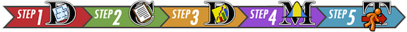

## Case Study: The Effects of Gratitude

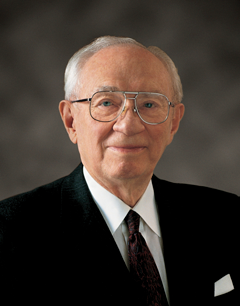

$~ ~$

President Gordon B. Hinckley said, "My plea is that we stop seeking out the storms and enjoy more fully the sunlight. I am suggesting that as we go through life, we ‘accentuate the positive.’ I am asking that we look a little deeper for the good, that we still our voices of insult and sarcasm, that we more generously compliment and endorse virtue and effort" (*Standing for Something*, 2000, p.101).

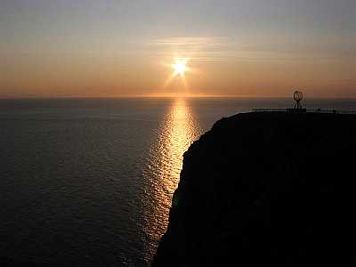

**Summarize the relevant background information**

Robert Emmons and Michael McCullough investigated the effects of gratitude on people’s perception of life as a whole. In a study of $n = 192$ undergraduates, the people were randomly assigned to one of three groups.

- Group 1 (Gratitude): The participants in this group were asked to record five things each week for which they were grateful or thankful.
- Group 2 (Hassles): The volunteers in this group recorded five irritants that had occurred to them in the previous week.
- Group 3 (Events): The people in the events group recorded five things that occurred in the past week that had an impact on them.

In addition to the weekly record of the five things they recorded their level of satisfaction with life in general. (Higher values are more favorable.) Reports were collected for nine weeks, and the overall level of satisfaction with life as a whole was recorded for each individual. The researchers wanted to determine if there was a difference in the perception of life as a whole between the subjects assigned to each of the three groups. Stated differently, they wanted to determine if expressing gratitude affects a person’s view of life in general.

Here is an excerpt of data representing the results of this study:

| Person | Treatment Group | Happiness Score |
| --- | --- | --- |
| 1 | Grateful | 6.1 |
| 2 | Grateful | 6.2 |
| $\vdots$ | $\vdots$ | $\vdots$ |
| 64 | Grateful | 4.9 |
| 65 | Hassles | 5.9 |
| $\vdots$ | $\vdots$ | $\vdots$ |
| 127 | Hassles | 3.8 |
| 128 | Events | 4.9 |
| $\vdots$ | $\vdots$ | $\vdots$ |
| 192 | Events | 3.7 |

Higher values indicate a greater level of satisfaction with life as a whole.

How might we analyze these data? One possible method would be to conduct separate t-tests for all the possible pairs of groups in the study. If we did this, we would need to conduct a separate t-test to compare groups 1 & 2, 1 & 3 and 2 & 3. If the probability of committing a Type I error is $\alpha = .05$ on each of these tests, then the probability that we would commit a Type I error on at least one of the tests is much greater than 0.05. We need a hypothesis test that we can use to compare all the groups at once. The procedure that allows us to do this is called Analysis of Variance (ANOVA).

## Analysis of Variance (ANOVA)

ANOVA, an acronym for **An**alysis **o**f **Va**riance, is a test for equality of several means. It allows us to compare the means for several groups in a single hypothesis test. It is based on a comparison of the spread (or variance) of the data *within* each of the groups compared to the spread (or variance) *between* the means of the groups.

In an ANOVA test, the null hypothesis is typically expressed in words:
$$H_0: \text{All the population means are equal.}$$
The alternative hypothesis is also stated in words as:
$$H_a: \text{One or more of the population means differs from the others.}$$

If the sample means differ from each other enough, then we conclude that the true population means for each group are not all equal. If the sample means do not differ by much (when compared to the spread of the data in each group) then we fail to reject the null hypothesis that all the populations means are equal.

We will use the level of significance, $\alpha$, and the $P$-value just as we have in the other hypothesis tests.

**State the null and alternative hypotheses and the level of significance**
$$\begin{align}
H_0: & ~ \textrm{The population mean happiness scores are equal for each treatment} \\
H_a: & ~ \textrm{At least one of treatments has a different population mean happiness score}
\end{align}$$

We will use the $\alpha = 0.05$ level of significance.

**Describe the data collection procedures**

The 192 students that volunteered to participate in the study were randomly assigned to one of the three treatment groups: Events, Hassles, or Gratitude. They wrote in a weekly journal, according to their group assignment. At the end of the semester, they completed a questionnaire that asked about their attitude toward life. The responses on the survey were coded into a number, where higher numbers represent a more positive outlook on life.

**Give the relevant summary statistics**

### R Instructions for Numerical Summaries of Several Groups (Long Data)

R Instructions

**To compute numerical summaries for several groups:**

- Read in the data: gratitude.xlsx. (Review of reading in data.)
- Load `library(mosaic)`. (If this fails for you, try running `install.packages("mosaic")` and then re-run the `library(mosaic)` command.)
- Use the `favstats(...)` function with the quantitative data column name listed first, followed by a tilde, `~`, which is followed by the categorical data column name. We indicate that these columns are part of the `gratitude` data frame using the command `data = gratitude`.

```r
library(mosaic)
favstats(happiness ~ treatment, data = gratitude)
```

```
  treatment min    Q1 median    Q3 max     mean        sd  n missing
1    Events 3.0 4.100   4.70 5.100 6.8 4.660000 0.8483071 65       0
2  Grateful 3.5 4.275   5.05 5.625 7.5 5.050000 0.9443231 64       0
3   Hassles 3.3 3.850   4.60 5.400 6.2 4.674603 0.8320143 63       0
```

### R Instructions for Side-by-Side Boxplots of Several Groups (Long Data)

R Instructions

**To make an appropriate graph to illustrate the data:**

- Use the `boxplot(...)` function with the quantitative data listed first, followed by a `~`, followed by the categorical data.
- Specify colors using either `col = "steelblue3"` to give all boxes the same color, or use `col = c("brown3","steelblue3","tan3")` to give each box a different color. Of course, use any color names you like.
- Specify axes labeling with `main = "A main title"`, `xlab = "An x-axis label"`, and `ylab = "A y-axis label"`.

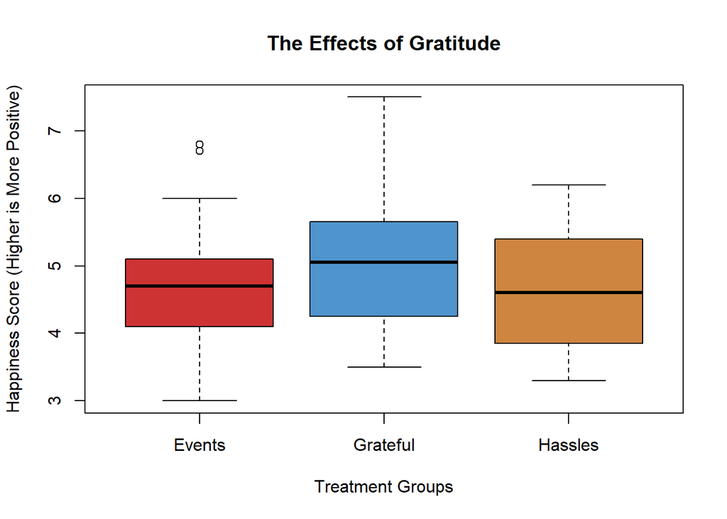

```r
boxplot(gratitude$happiness ~ gratitude$treatment,
        col = c("brown3","steelblue3","tan3"),
        main = "The Effects of Gratitude",
        xlab = "Treatment Groups",
        ylab = "Happiness Score (Higher is More Positive)")
```

Based on the numerical summaries and boxplot, the gratitude group had a higher life happiness mean score of 5.05 compared to the other two groups of 4.66 (Events group) and 4.67 (Hassles group). This suggests that perhaps exercising a daily recognition of things one is grateful for can result in greater life satisfaction. However, it is important to first **make inference** before we decide if the data really warrants this conclusion.

**Make Inference**

### R Instructions for Conducting an ANOVA Test (Long Data)

R Instructions

To conduct a test for several means (ANOVA) in R, do the following:

- Read in the data if you haven’t already: gratitude.xlsx. (Review of reading in data.)
- Use the `aov(...)` function and the assignment operator `<-` to perform and save the results of the test to any name you want to create for the test. Here we use the name `aov_output`.
- When using the `aov(...)` function, place the quantitative variable first, followed by a `~`, followed by the categorical variable. As in other examples, we indicate the data frame using the `data =` argument.
- Use the `summary(...)` function to view the results of the ANOVA test in a nice format.

```r
aov_output <- aov(happiness ~ treatment, data = gratitude)
summary(aov_output)
```

```
             Df Sum Sq Mean Sq F value Pr(>F)
treatment     2   6.26   3.130   4.075 0.0185 *
Residuals   189 145.16   0.768
---
Signif. codes:  0 '***' 0.001 '**' 0.01 '*' 0.05 '.' 0.1 ' ' 1
```

In the ANOVA table output summary, you will find

- the test statistic ($F$, see **The $F$-Distribution** section below for an explanation),
- the $P$-value (Pr(>F)),
- and the two separate degrees of freedoms (Df) for the $F$ statistic.

Note that there are two numbers specifying the degrees of freedom. These are given as the “Treatment Group” and “Residuals” degrees of freedom, respectively. The degrees of freedom for the “Treatment Group” are one less than the number of groups, in this case there are three groups (Events, Hassles, and Grateful) so there are 2 degrees of freedom. The “Residuals” degrees of freedom is equal to the total sample size ($n = 192$ in this study) minus 1, then minus the Df for the “Treatment Group”, which is 2 in this case. That leaves us with $192 - 1 - 2 = 189$ “residual” degrees of freedom (or leftover degrees of freedom).

More advanced statistics courses will go deeper into explaining these degrees of freedom and why they matter. For now, just recognize that the “Df” values are used to obtain the “Mean Sq” values by dividing the “Sum Sq” values by the “Df” values. Then, the “F value” is obtained by dividing the two “Mean Sq” values. These “Mean Sq” values are essentially *variances* and thus the name of the method is called “Analaysis of Variance” or ANOVA because the F-statistic is the ratio of two variances. When the F-statistic is large, that tells us that the means are farther apart than we would expect if all samples were from the same population of data.

### The $F$-distribution

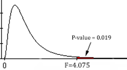

The test statistic in ANOVA follows an $F$-distribution. This is the first time we have encountered this distribution. In previous tests, we have used the test statistics $z$ and $t$. For the ANOVA test, we use the $F$-statistic.

Here is a brief summary of the characteristics of the $F$-distribution:

- It is right skewed.
- The values of $F$ are never negative.
- The $P$-value for the ANOVA test is the area in the *right tail*. We will never divide the area in the tail.

### Requirements of ANOVA

**Verify the requirements have been met.**

There are two requirements of ANOVA that we can verify directly:

- The data are normally distributed in each group.

  We can check this by looking at the boxplots we created previously. If each boxplot is relatively symmetric and there are no major outliers, it is reasonable to conclude that the data are sufficiently normal to proceed with the analysis. We can take this approach because ANOVA is robust to violations of requirements. In other words, results from ANOVA tests are reasonably good even if there are mild to moderate violations of the requirements.

  In looking at the boxplot of the gratitude data above, we see the median is in the center of each box (it isn’t pressed up against either end of the box) and that the whiskers of each box go out somewhat equally to either side of the box. While there are a couple of outliers in the Events group, and the top whisker for the “Grateful” group is longer than its bottom whisker, this would be considered a very “normally distributed” set of boxplots.
- The variances are equal for each group.

  We can find the variance using the following R command:

```r
var(happiness ~ treatment, data=gratitude)
```

```
##    Events  Grateful   Hassles
## 0.7196250 0.8917460 0.6922478
```

[output not shown]

The variance is the square of the standard deviation. The sample variance is denoted by the symbol $s^2$.

**Give the test statistic and its value**

This can be found in the output. Our test statistic, $F$, is:
$$F = 4.075$$

**State the degrees of freedom**

There are 2 and 189 degrees of freedom.

The order in which these are stated is important. For an F-test, it is not the same to have 2 and 189 degrees of freedom as it is to have 189 and 2 degrees of freedom.

**Mark the test statistic and $P$-value on a graph of the sampling distribution**

While this is not something that you have to do in this course, it is good to remember that the $P$-value provided to you in the output of the ANOVA test in R is the “probability of obtaining a test statistic as extreme or more extreme than the one observed, assuming the null hypothesis is true.” That is why the notation for it in the summary output is `Pr(>F)`. If we drew a picture of the F-distribution we would see that it starts at zero, is strongly right-skewed, and goes to infinity. Marking the observed test statistic on the graph and shading the area to the right would give the p-value.

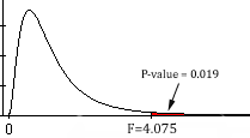

**Find the $P$-value and compare it to the level of significance**

The $P$-value of the ANOVA test can be found in the output summary of the test.
$$P\textrm{-value} = 0.019 < 0.05 = \alpha$$

**State your decision**

Since $P$-value$ = 0.019 < 0.05 = $, we reject the null hypothesis.

**Present your conclusion in an English sentence, relating the result to the context of the problem**

There is sufficient evidence to suggest that at least one of the three groups has a mean level of satisfaction with life that differs from the others. In short, the mean level of satisfaction with life in general is not the same for all three groups.

## ANOVA with Wide Data: Soccer Shoes

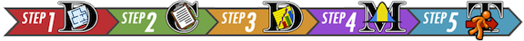

**Summarize the relevant background information**

Nike, a company that makes sporting goods including shoes, funded a study to compare five soccer shoe designs. The objective of the research was to determine if there is a difference in the mean accuracy soccer players achieve using different Nike shoe designs.

Data representing the results of this study are given in the file soccer_shoes. (Review of reading in data.)

### R Instructions for Converting “Wide” Data to “Long” Format

After reading in the data, examine the format in which they are presented.

Here are the first eight rows:

| shoe_a | shoe_b | shoe_c | shoe_d | shoe_e | socks | comments |
| --- | --- | --- | --- | --- | --- | --- |
| 35 | 30 | 25 | 26 | 43 | 34 | These data are based on Figure 5 in the article: |
| 32 | 27 | 40 | 19 | 30 | 37 | The influence of soccer shoe design on playing performance: a series of |
| 39 | 27 | 35 | 32 | 38 | 46 | biomechanical studies |
| 44 | 38 | 30 | 37 | 36 | 39 | Ewald M. Hennig and Thorsten Sterzing |
| 35 | 36 | 23 | 29 | 27 | 27 | NA |
| 27 | 31 | 24 | 43 | 30 | 37 | Hennig, Ewald M. and Sterzing, Thorsten(2010) ’The influence of soccer shoe design on playing |
| 28 | 36 | 31 | 38 | 34 | 41 | performance: a series of biomechanical studies’, Footwear Science, 2: 1, 3 — 11 |
| 31 | 36 | 28 | 30 | 25 | 37 | NA |

There are six columns of data, where each column gives the accuracy rating for a different type of footwear. Note that this is wide data, since every column gives the data for one group. The last column provides the reference for the articles from which the data were derived.

In order to conduct an ANOVA analysis to determine if the mean accuracy is the same for the six types of footwear, we need to convert the data into “long” format. We will do this in three steps:

1. Examine the data. We can either do this with either the `View(soccer_shoes)` or `head(soccer_shoes)` commands.
2. Remove columns that do not contain data. In this case, we want to eliminate the column titled `comments`. One way to do this is by running the command:

```r
soccer_shoes$comments <- NULL
```

This command removes the column `comments` from the data set. The only way to restore the column is to start over by reading in the data again.

3. We will use the `stack()` command to create a new data set called `soccer` that is in “long” format:

```r
soccer <- stack(soccer_shoes)
```

Use `View(soccer)` to explore these data. Notice that R has transformed the data, so that it is now in “long” format, where the accuracy values are in a column called `values` and the label indicating (“ind”) the type of footwear is in a second column called `ind`.

After making this change, the techniques for performing ANOVA on long data can be applied to the data set `soccer`.

**State the null and alternative hypotheses and the level of significance**
$$\begin{align}
H_0: & \textrm{All the means are equal} \\
H_a: & \textrm{At least one of the means differs}
\end{align}$$

We will use the $\alpha = 0.10$ level of significance.

**Describe the data collection procedures**

As part of the research, they asked trained soccer players to kick a ball at a target. The target was placed 115 cm above the ground and at a distance of 10 m from the players. Using electronic equipment, the researchers recorded the distance from the center of the target to the point where the ball hit. The objective of the research was to assess if footwear could affect the accuracy of a soccer player.

The subjects wore five different soccer shoes and for one treatment they kicked the ball in stocking feet. Due to the proprietary nature of the data, the shoes are only labeled “A,” “B,” “C,” “D,” and “E” in the article. Use the soccer shoes to answer the following questions.

Answer the following questions:

1. **Give the relevant summary statistics**

Show/Hide Solution

2. **Make an appropriate graph to illustrate the data**

Show/Hide Solution

3. Based on what you have seen so far, does it appear that there is a significant difference between the mean accuracy of the kicks using the six types of footwear?

Show/Hide Solution

4. Which types of footwear seem to be giving the greatest accuracy?

Show/Hide Solution

Answer the following questions:

5. **Verify the requirements have been met**

Show/Hide Solution

6. **Give the test statistic and its value**

Show/Hide Solution

7. **State the degrees of freedom**

Show/Hide Solution

8. **Mark the test statistic and $P$-value on a graph of the sampling distribution**

Show/Hide Solution

9. **Find the $P$-value and compare it to the level of significance**

Show/Hide Solution

10. **State your decision**

Show/Hide Solution

Answer the following questions:

11. **Present your conclusion in an English sentence, relating the result to the context of the problem**

Show/Hide Solution

## Summary

Remember…

- **ANOVA** is used to compare the means for several groups. The hypotheses for the test are always:
  $$\begin{align}
  H_0: & ~ \textrm{All the means are equal} \\
  H_a: & ~ \textrm{At least one of the means differs}
  \end{align}$$
- For ANOVA testing we use an **$F$-distribution**, which is right-skewed. The $P$-value of an ANOVA test is always the area to the right of the $F$-statistic.
- We can conduct ANOVA testing when the following requirements are satisfied:
  1. The data come from a simple random sample.
  2. The data are normally distributed within each group.
     - This is considered met unless one or more of the groups has a *strongly* skewed distribution.
  3. The variance is constant.
     - This is satisfied when the largest variance is not more than four times the smallest.
- To perform an ANOVA in R, use the code `aov_output <- aov(...)` to run the test, then the code `summary(aov_output)` to view the results.
- If data are provided in “wide” format, they must first be converted to “long” format before performing the ANOVA analysis.

## Navigation

| **Previous Reading** | **This Reading** | **Next Reading** |
| --- | --- | --- |
| Lesson 13: Inference for Two Means: Independent Samples | Lesson 14: Inference for Several Means (ANOVA) | Lesson 15: Review for Exam 2 |